# A14.5 単純な断面の最大せん断応力

# A14.6 撓みせん断流方程式の導出：対称梁断面

基本的な関係をさらに強調するために、せん断応力分布方程式の2つ目の導出方法を提示する。  
図 A14.14 は、自由端に荷重 $P$ を受ける片持ち梁の一部を示している。  
この荷重は、梁が $Y$ 軸のまわりにねじれることなく $YZ$ 平面内で曲がるような位置に作用している。ここでの課題は、梁の断面におけるせん断流分布の大きさと方向を与える関係式を導出することである。

図 A14.15 は、図 A14.14 の点 (a, b) において、梁の上部フランジから切り取られた小さな要素のフリーボディ（自由体）を示している。与えられた外荷重 $P$ の下で、梁の上半半分には圧縮応力が作用していることは明らかである。図 A14.15 において、片持ち梁の曲げモーメントは位置 $Y'$ の方が大きいため、 $C'_y$ は $C_y$ よりも大きくなる。

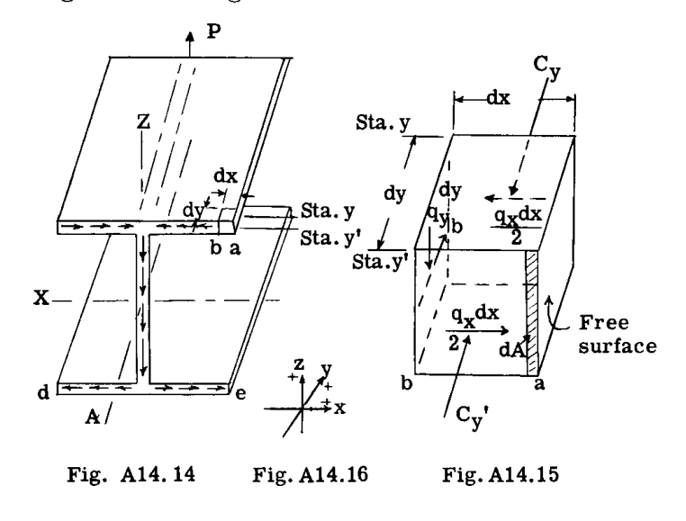

図 A14.14, Fig. A14.16, Fig. A14.15

梁フランジの自由端は、図 A14.15 の要素の右側面を形成しているため、この面に作用するせん断流による力は、図に示されているようにゼロである。内側の切り口の面に作用する単位長さあたりのせん断流による力は、図示のように $q_y$ および $q_x$ (lbs. per inch) である。これらのせん断力の向きは未知であるため、正の方向に作用しているものと仮定する（座標軸 XYZ のそれぞれに平行に作用する力の正の向きについては、図 A14.16 を参照されたい）。

ここで、図 A14.15 の要素における $Y$ 方向の力のつり合いを考える。
$$\Sigma F_y = 0$$
または、
$$_y q_b \text{ dy} + (C'_y - C_y) = 0$$
したがって、
$$_y q_b = - \frac{(C'_y - C_y)}{\text{dy}}$$
しかし、
$$(C'_y - C_y) = \frac{M'_x - M_x}{I_x} \int_a^b z \text{ dA} \quad \text{（A14.3節を参照）}$$
したがって、
$$_y q_b = - \frac{\text{dM}_x}{\text{dy} I_x} \int_a^b z \text{ dA}$$
ここで、
$$\frac{\text{dM}}{\text{dy}} = V_z$$
（ $Z$ 方向の外力せん断力）である。

したがって、
$$_y q_b = - \frac{V_z}{I_x} \int_a^b z \text{ dA} \quad \text{--- (7)}$$

式 (7) は、点 (a) と点 (b) の間におけるせん断流の力 $q_y$ の変化量を示している。図 A14.15 において、点 (a) は自由表面であるため $q_y$ の値はゼロであり、したがって式 (7) における $_y q_b$ の値は、点 (b) における実際のせん断流の力 (lbs. per inch) となる。読者は、式 (7) が $Y$ 方向のせん断流 $q$ を与えていることを理解すべきである。式 (7) のマイナス符号は、図 A14.15 の $_y q_b$ に示された矢印の向きとして仮定した正の向きが誤りであり、逆向きにする必要があることを意味している。

当初の目的は、梁の断面内（すなわち $ZX$ 平面内）のせん断流力系を決定することであった。初等材料力学から、物体内のある点のある平面上にせん断応力が発生すると、その平面と直交する平面上にも同じ強さのせん断応力が存在することが分かっている。すなわち、一般に一点において、
$$q_y = q_x = q_z \quad \text{--- (8)}$$
である。

他の平面におけるせん断流が完全に定義される前に、その向き（正か負か）を知る必要がある。式 (7) は、断面上の任意の点における $q_y$ の大きさと向きを与える。これに関連する $q_x$ および $q_z$ の向きは、モーメントのつり合いを観察することによって容易に決定できる。この事実について、いくつかの自由体図を参照しながら説明する。

図 A14.17 は、図 A14.14 の断面上の点 (a) から切り取られた微小要素の自由体を示している。この自由体に作用する力は、前面および背面に作用する圧縮力 $C'$ および $C$ と、図示された各面に作用するせん断力である。要素の右側面は自由表面であるため、この面における $q$ はゼロである。

左側面におけるせん断流 $q_y$ は、式 (7) すなわち次の式から計算される。
$$q_y = - \frac{V_z}{I_x} \Sigma z A$$

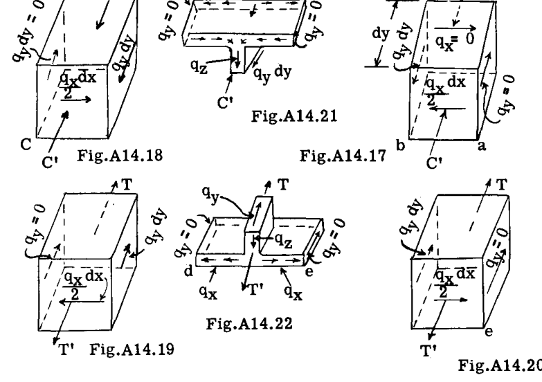

図 A14.18, Fig. A14.21, Fig. A14.17, Fig. A14.19, Fig. A14.22, Fig. A14.20

図 A14.14 に示された梁の荷重条件において、荷重 $P$ は上向きであるため、 $V_z$ は正の符号を持つ。断面の任意の面積領域 ( $A$ ) について、上記の方程式における距離 $z$ は中立軸より上にあるため正である。したがって、上記の方程式に代入すると、中立軸より上の任意の点において $q_y$ は負となり、同様に中立軸より下の任意の点においては、距離 $z$ が負の符号を持つため $q_y$ は正となる。したがって、図 A14.17 の要素の左側面における計算されたせん断流 $q_y$ の向きは負、すなわち力ベクトル上の矢印で示された方向になる。  
次に、前面におけるせん断流 $q_x$ の向きを求めるために、背面の平面内にあり、力 $C'$ および $C$ の作用線上にある点 (O) を通る $Z$ 軸のまわりのモーメントのつり合いを考える。モーメントを持つ力は、側面のせん断力 $q_y \text{ dy}$ と、前面のせん断力 $(q_x/2)\text{dx}$ の2つだけである。モーメントがゼロになるためには、前面の $q_x$ は図示のように左向きに作用しなければならないことは明らかである。右端のせん断流がゼロで、左端の $q_x$ まで線形に変化するため、前面における全せん断力は $(q_x/2)\text{dx}$ となる。

図 A14.18、19、20 は、図 A14.14 で c, d, e とラベルされた、梁断面の他の3つの角から取り出された要素の自由体を示している。すべての自由表面において $q$ はゼロである。前述の説明と同様に、 $q_y$ の向きは方程式から得られ、したがって $q_y$ は図 A14.18 では負、図 A14.19 および 20 では正となる。図 A14.17 で説明したのと同様に、モーメントのつり合いを簡単に考慮することで、これら3つの図に示されているせん断流 $q_x$ の向きが得られる。

図 A14.21 は、上部フランジ全体と梁ウェブの短い部分の自由体を示している。方程式から得られる $q_y$ は負であり、図に示すように作用する。ここで、背面の平面内にあり $C'$ と $C$ の作用線上の点を通る $X$ 軸のまわりのモーメントを考えると、前面におけるせん断流 $q_z$ は、 $q_y$ によるモーメントとつり合わせるために下向きに作用しなければならない。

図 A14.22 は、下部フランジとウェブの小さな部分についての自由体を示したものである。式から $q_y$ は正となり、したがってモーメントのつり合いのために $q_z$ は下向きでなければならない。

これら6つの異なる位置から得られた結果から、断面の平面内におけるせん断流の向きに関して、以下のような簡単なルールを述べることができる。  
**「計算されたせん断流が、特定の自由体の2つの交差する平面の境界線に向かっている場合、もう一方の平面上のせん断流もその共通の境界線に向かい、逆に、計算されたせん断流が境界線から離れる向きである場合は、もう一方も離れる向きになる。」**

図 A14.14 は、与えられた外荷重に対して決定された、梁断面上のせん断流パターンの向きを示している。

## A14.7 1つの対称軸を持つ梁断面のせん断応力とせん断中心

### 例題：チャンネル断面（溝形鋼）

図 A14.23 は、図示のように 100 lb. の下向き荷重を受ける、チャンネル形状の断面を持つ片持ち梁を示している。課題は、この梁がねじれることなく曲がるように、この荷重の横方向の位置を決定することである。この位置は、梁の断面におけるせん断流システムの合力の横方向位置（重心）と一致し、梁断面にねじれを生じさせることなく外荷重とつり合う。  
片持ち梁は、梁の固定端（図示せず）から十分に離れた断面 a-b-c-d（図 A14.23）で切断されており、断面の歪み（ワーピング）に対する梁端部拘束の影響は無視できるものとする。図 A14.23 には、梁をつり合い状態に保つ内力がスケッチされている。これらは、引張と圧縮の軸方向応力システムと、断面内の変化するせん断流システムから構成されている。この問題では、内部の抵抗せん断流システムのみを考慮する。

この問題を解決するには、断面二次モーメント $I_x$ を知る必要がある。計算すると、 $I_x = 0.2667 \text{ in}^4$ である。

**解法：**
式 (7) より、
$$q_y = - \frac{V_z}{I_x} \Sigma z A \quad \text{--- (8)}$$
自由端においてせん断応力はゼロであることが分かっているため、式 (8) の解は点 (a) または (d) のいずれかから開始される。
せん断力 $V_z$ は $-100 \text{ lb.}$ である。したがって、この問題に対する式 (8) は次のようになる。
$$q_y = - \frac{-100}{0.2667} \Sigma z A = 375 \Sigma z A \quad \text{--- (9)}$$

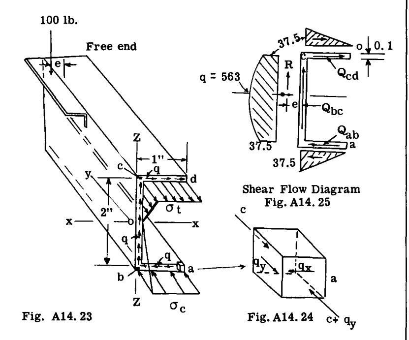

図 A14.23, Fig. A14.25, Fig. A14.24

式 (9) を解くにあたり、点 (a) から開始し、断面に沿って進む。
点 (a) では、
$$_y q_a = 0 \quad \text{（自由表面）}$$

点 (b) では、 $z = -1$ 、 $A = \text{ (a) と (b) の間の面積}$ である。
$$_y q_b = _y q_a + 375 \int_a^b z \text{ dA}$$
$$_y q_b = 0 + 375 (-1)(1 \times 0.1) = -37.5 \text{ lb./in.}$$

$X$ 軸上の点 (0) において、
$$_y q_o = -37.5 + 375 \int_o^b z \text{ dA}$$
$$_y q_o = -37.5 + 375 (-0.5)(1 \times 0.1) = -56.3 \text{ lb./in.}$$

点 (c) において、
$$_y q_c = -56.3 + 375 (0.5)(1 \times 0.1) = -37.5 \text{ lb./in.}$$

点 (d) において、
$$_y q_d = -37.5 + 375 (1)(1 \times 0.1) = 0 \quad \text{（自由表面）}$$

$ZX$ 平面内の任意の点におけるせん断流の強さは、同じ点における $Y$ 方向の強度に等しいことが分かっている。したがって、 $q_x$ または $q_z$ は上記の $q_y$ の値に等しい。 $q_x$ および $q_z$ のせん断流の向きは、完全に定義または把握される前に知っておく必要がある。図 A14.24 は、下部梁フランジの端にある点 (a) における微小要素の自由体を示している。 $X$ 図心軸より下の任意の点について、式 (9) は $q_y$ に対してマイナスの符号を与える。したがって、図 A14.24 において、 $q_y$ は図示のように作用するか、または側面と前面の間の境界線に向かう方向になる。その場合、前の節で説明した簡単なルールにより、 $q_x$ もこの共通の境界線に向かう方向になる（図 A14.24 を参照）。

常識的に考えて、チャンネルウェブ上の抵抗せん断流 $q_z$ は、 $\Sigma F_z = 0$ に関して 100 lb. の荷重とつり合うことができる唯一の力システムであるため、上向きでなければならない。

一般に、せん断流は断面の周囲で連続しており、閉じた管状断面でしか発生しないゼロを通過するときにのみ反転する。一般に、ほとんどの場合、観察するだけで梁断面のどこか1点におけるせん断流の向きを決定することができる。せん断流は流体の流れのようであり、梁断面を構成する部品の中心線に沿って同じ一般的な方向に流れ続ける。

図 A14.23 の梁断面上の小さな矢印は、梁断面全体のせん断流パターンの向きを示している。図 A14.25 では、様々な点において計算されたせん断流の値がプロットされ、梁断面のせん断流図を形成している。点 a と b、または d と c の間では、式 (9) における距離 $z$ は一定であるため、 $q$ はプロットされているように線形に変化する。b と O、または O と c の間では、距離 $z$ が変化し、面積も $z$ の関数となるため、 $q$ は $z^2$ に比例して、またはプロットされているように放物線状に変化する。

当初の問題は、一般にせん断中心と呼ばれる、この最終的なせん断流システムの合力の作用位置を特定することであった。図 A14.25 において、 $Q_{ab}$ 、 $Q_{bc}$ 、および $Q_{cd}$ は、梁断面のこれら3つの部分におけるせん断流力システムの合力を表している。各力の大きさは、特定の梁断面部分に対するせん断流図の面積に等しい。したがって、
$$Q_{ab} = 1 \times 37.5 / 2 = 18.75 \text{ lb.}$$
$$Q_{bc} = 2 \times 37.5 + (56.3 - 37.5) \times 2 \times 2/3 = 100 \text{ lb.}$$
$$Q_{cd} = 1 \times 37.5 / 2 = 18.75 \text{ lb.}$$

これら3つのせん断力の合力 $R$ を決定する。
$$\Sigma F_z = 100 \text{ lb.},$$
$$\Sigma F_x = 18.75 - 18.75 = 0$$
したがって、
$$R = \left( (\Sigma F_z)^2 + (\Sigma F_x)^2 \right)^{1/2} = (100^2 + 0)^{1/2} = 100 \text{ lb.}$$

したがって、内部のせん断抵抗力システムの合力作用位置は、図 A14.23 に示されているように、点 (b) から左に 0.375 インチの垂直線上にある。 $X$ 図心軸に対して断面が対称であるため、ねじれを伴わずに図心 $Z$ 軸のまわりに曲げる場合、内部せん断流システムの合力は明らかに $X$ 軸上にある。したがって、与えられたチャンネル断面のせん断中心は、図 A14.23 の点 O にある。ねじれを伴わない梁の曲げが発生するためには、100 lb. の外荷重は、チャンネルウェブの中心線から左に 0.375 インチの位置になければならない。

# A14.8 非対称梁断面のせん断応力

梁の曲げ応力を扱った A13 章では、非対称な梁断面を持つ梁の曲げ応力を決定するための3つの方法が提示された。これら3つの方法に対する曲げ応力の方程式をここに再掲する。

### 方法 1. 主軸法

$$\sigma = - \frac{M_{xp} z_p}{I_{xp}} - \frac{M_{zp} x_p}{I_{zp}} \quad \text{--- (9)}$$

### 方法 2. 中立軸法

$$\sigma = - \frac{M_n z_n}{I_n} \quad \text{--- (10)}$$

### 方法 3. 図心 Z および X 軸まわりの断面特性を用いる方法

簡潔にするため、この方法は $k$ 方法と呼ばれる。
$$\sigma = - (k_3 M_z - k_1 M_x) x - (k_2 M_x - k_1 M_z) z \quad \text{--- (11)}$$
ここで、
$$k_1 = \frac{I_{xz}}{I_x I_z - I_{xz}^2} , \quad k_3 = \frac{I_x}{I_x I_z - I_{xz}^2}$$
$$k_2 = \frac{I_z}{I_x I_z - I_{xz}^2}$$

式 (5)、(6)、および (7) の導出に立ち返ると、上記の式 (9)、(10)、および (11) は、外力曲げモーメントの代わりに梁の外力せん断力を用いて、以下のように書き換えることができる。

### 方法 1. 主軸法

$$q_y = - \frac{V_{zp}}{I_{xp}} \Sigma z_p A - \frac{V_{xp}}{I_{zp}} \Sigma x_p A \quad \text{--- (12)}$$

### 方法 2. 中立軸法

$$q_y = - \frac{V_n}{I_n} \Sigma z_n A \quad \text{--- (13)}$$

### 方法 3. $k$ 方法

$$q_y = - (k_3 V_x - k_1 V_z) \Sigma x A - (k_2 V_z - k_1 V_x) \Sigma z A \quad \text{--- (14)}$$

### 3つの異なる方法を用いた例題

図 A14.26 は、図示のように、断面のせん断中心を通り、図示の方向に作用する 10,000 lb. のせん断荷重を受ける Z 形断面を示している。課題は、梁断面上の2つの点、すなわち図に示されている点 b と c におけるせん断流 $q_y$ を計算することである。これら2つの場所におけるせん断流は、3つすべての方法によって計算される。

3つの方法すべてにおいて梁の断面特性を使用する必要があり、主軸または中立軸の方向が未知であるため、どの方法を使用するかに関わらず、最初のステップは図心 $X$ および $Z$ 軸に関する断面特性を計算することである。表 A14.3 はその計算を示している。断面は、1、2、3、および 4 とラベルされた 4 つの部分に分割されている。

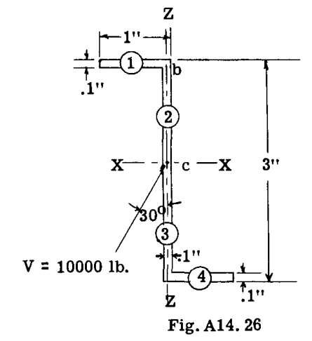

図 A14.26

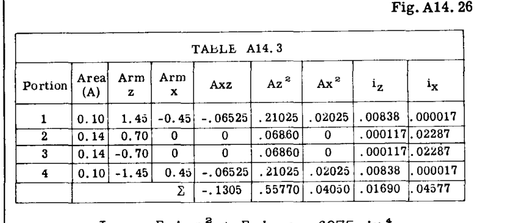

表 A14.3

$$I_x = \Sigma A z^2 + \Sigma i_x = .6035 \text{ in}^4$$
$$I_z = \Sigma A x^2 + \Sigma i_z = .0574$$
$$I_{xz} = \Sigma A x z = -.1305$$
（注：表 A14.3 において、 $i_x$ および $i_z$ は、各部分のそれ自身の図心軸まわりの断面二次モーメントである）。

### 主軸法による解法（方法 1）

$\phi$ を主軸と $X$ および $Z$ 軸の間の角度とする。A13 章より、
$$\tan 2\phi = \frac{2 I_{xz}}{I_z - I_x} = \frac{2(-0.1305)}{0.0574 - 0.6035} = 0.4778$$
したがって、
$$2\phi = 25^\circ - 32.2' \quad \text{または} \quad \phi = 12^\circ - 46.1'$$
$$\sin \phi = 0.2210 \quad \text{および} \quad \cos \phi = 0.97527$$

主軸まわりの断面二次モーメントを計算することができる。
$$I_{xp} = I_x \cos^2 \phi + I_z \sin^2 \phi - 2 I_{xz} \sin \phi \cos \phi$$
$$= 0.6035 \times .97527^2 + .0574 \times .2210^2 - 2 (-0.1305) \times .97527 \times .2210 = .63316 \text{ in}^4$$
$$I_{zp} = I_x \sin^2 \phi + I_z \cos^2 \phi + 2 I_{xz} \sin \phi \cos \phi$$
$$= 0.6035 \times 0.2210^2 + .0574 \times .97527^2 + 2 (-0.1305) \times .97527 \times 0.2210 = 0.02782 \text{ in}^4$$

せん断流 $q$ に対する方程式は、
$$q = - \frac{V_{zp}}{I_{xp}} \Sigma z_p - \frac{V_{xp}}{I_{zp}} \Sigma x_p \quad \text{--- (15)}$$

図 A14.26 において、外力せん断荷重は図示の方向に作用する 10000 lbs. である。このせん断荷重を $z$ および $x$ 成分に分解すると、以下が得られる。
$$V_z = 10000 \times \cos 30^\circ = 8667 \text{ lb.}$$
$$V_x = 10000 \times \sin 30^\circ = 5000 \text{ lb.}$$

これらの $z$ および $x$ 成分を主軸に沿った成分にさらに分解すると、以下が得られる。
$$V_{zp} = 8667 \times .97527 - 5000 \times .2210 = 7348 \text{ lb.}$$
$$V_{xp} = 8667 \times .2210 + 5000 \times .97527 = 6792 \text{ lb.}$$

点 (b) におけるせん断流の計算（図 A14.26 を参照）。  
図 A14.27 は、計算された主軸の位置を示している。上部（1）の自由端におけるせん断流はゼロである。点 (b) におけるせん断流について、総和 $\Sigma z_p A$ および $\Sigma x_p A$ で使用される面積は、要素（1）の面積である。距離 $z_p$ および $x_p$ は、簡単な三角関数によって計算することができる。図 A14.27 はこれらの距離の値を示しており、すなわち $x_p = -0.1184$ 、 $z_p = 1.5136$ である。

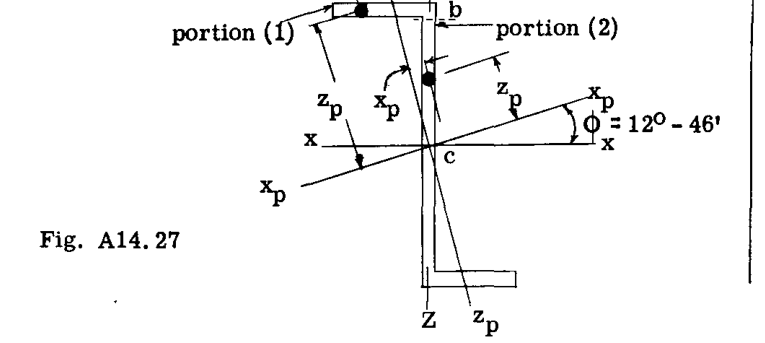

図 A14.27

ここで、式 (15) に代入すると、
$$q_b = - \frac{7348}{0.63316} (1 \times 0.1 \times 1.5136) - \frac{6792}{0.02782} (1 \times 0.1)(-0.1184) = -1756 + 2890$$
$$= 1134 \text{ lb./in.}$$

点 (c) におけるせん断流の計算。
部分 (2) について、面積 $A = 1.4 \times 0.1 = 0.14$
$$z_p = .70 \times .97527 = 0.6825 \text{ in.}$$
$$x_p = .70 \times .2210 = 0.1547$$

点 (c) におけるせん断流は、点 (b) におけるせん断流に、点 (b) と (c) の間の部分 (2) の影響を加えたものに等しく、したがって、
$$q_c = 1134 - \frac{7348}{0.63316} (0.14 \times 0.6825) - \frac{6792}{0.02782} (0.14 \times 0.1547) = 1134 - 1109 - 5285$$
$$= -5260 \text{ lb./in.}$$

これら2つの点 (b) と (c) におけるせん断応力は、 $q/t = 1134/0.1$ および $-5260/0.1$ 、すなわちそれぞれ 11340 psi および -52600 psi となる。

### 中立軸法による解法（方法 2）

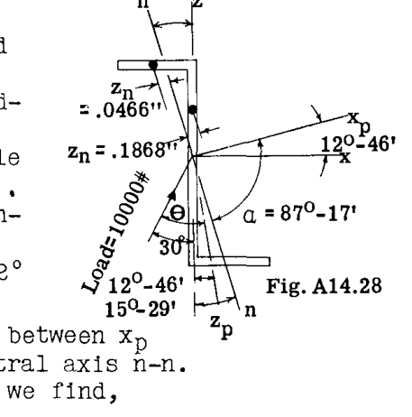

図 A14.28

この解決策では、与えられた外荷重に対する中立軸を見つける必要がある。図 A14.28 において、角度 $\theta$ は荷重平面と $z_p$ 主軸との間の角度であり、この角度 $\theta$ は $30^\circ + 12^\circ - 46' = 42^\circ - 46'$ に等しい。
$a$ を $x_p$ 主軸と中立軸 $n-n$ との間の角度とする。
A13 章より、以下が得られる。
$$\tan a = - \frac{I_{xp} \tan \theta}{I_{zp}} = - \frac{0.63316 \times 0.9245}{0.02782} = -21.052$$
したがって、 $a = -87^\circ - 17'$ である（中立軸の位置については図 A14.28 を参照）。
$$\sin a = 0.9989 , \quad \cos a = 0.04742$$
$$I_n = I_{xp} \cos^2 a + I_{zp} \sin^2 a$$
代入すると、
$$I_n = 0.63316 \times .04742^2 + .02782 \times .9989^2 = .02919$$

与えられた外力せん断荷重の中立軸 $n-n$ に垂直な成分は、以下に等しい。
$$V_n = 10000 \times \sin(45^\circ - 29') = 7130 \text{ lb.}$$

式 (13) より、
$$q = - \frac{V_n}{I_n} \Sigma z_n A$$

点 (b) におけるせん断流：
中立軸から部分 (1) の図心までの距離は $z_n = -0.0466 \text{ in.}$ である。
したがって、
$$q_b = - \frac{7130}{.02919} (1 \times 0.1)(-0.0466) = 1135 \text{ lb./in.}$$

点 (c) におけるせん断流： $z_n = 0.1868 \text{ in.}$
$$q_c = 1135 - \frac{7130}{.02919} (1.4 \times 0.1) .1868 = 1135 - 6390 = -5255 \text{ lb./in.}$$

### 方法 3 による解法（ $k$ 方法）

この方法では、図心 $X$ および $Z$ 軸に関する断面特性のみが必要である。表 A14.3 で以前に計算されたこれらの特性は、以下の通りである。
$$I_x = 0.6035, \quad I_z = 0.0574, \quad I_{xz} = -0.1305$$
式 (14) からのせん断流方程式は、
$$q = - (k_3 V_x - k_1 V_z) \Sigma x A - (k_2 V_z - k_1 V_x) \Sigma z A \quad \text{--- (16)}$$
$$k_1 = \frac{I_{xz}}{I_x I_z - I_{xz}^2} = \frac{-0.1305}{0.6035 \times .0574 - (-0.1305)^2} = \frac{-0.1305}{.01762} = -7.406$$
$$k_2 = \frac{I_z}{I_x I_z - I_{xz}^2} = \frac{0.0574}{.01762} = 3.257$$
$$k_3 = \frac{I_x}{I_x I_z - I_{xz}^2} = \frac{0.6035}{0.01762} = 34.25$$

10,000 の外力せん断荷重を $x$ および $z$ 成分に分解すると、以下が得られる。
$$V_x = 10000 \sin 30^\circ = 5000 \text{ lb.}$$
$$V_z = 10000 \cos 30^\circ = 8667 \text{ lb.}$$

$V_x$ 、 $V_z$ 、および $k$ の値を式 (16) に代入すると、以下が得られる。
$$q = - \left[ 34.25 \times 5000 - (-7.406 \times 8667) \right] \Sigma x A - \left[ 3.257 \times 8667 - (-7.406 \times 5000) \right] \Sigma z A$$
したがって、
$$q = -235438 \Sigma x A - 65258 \Sigma z A$$

点 (b) におけるせん断流：
部分 (1) について、 $x = -0.45 \text{ in.}$ 、 $z = 1.45 \text{ in.}$ である。
$$A = 1 \times 0.1 = .1$$
代入すると、
$$q_b = -235438 (-0.45) 0.1 - 65258 \times 1.45 \times 0.1 = 10597 - 9462 = 1135 \text{ lb./in.}$$

### 一般的なコメント

著者は、方法 1 や 2 で必要とされる追加の角度や断面特性の計算を回避できるため、解決方法として方法 3 を好む。さらに、飛行機の翼、胴体、およびその他の主要な構造ユニットにおけるせん断力とモーメントを計算する場合、これらのせん断力とモーメントを従来の $X, Y, Z$ 軸に関連付けるのが便利であり、したがってこれらの値は、さらなる分解を行うことなく方法 3 で直接使用することができる。多くの飛行機応力解析レポートの調査から、ほとんどの航空機会社の技術者は方法 3 を使用することを好むようである。

## A14.9 一定のせん断流ウェブを持つ梁

図 A14.29 は、厚いフランジ部材と湾曲した薄いウェブで構成された梁を示している。 $X-X$ 軸まわりの曲げに対して、梁の圧縮側にあるウェブは、ウェブの座屈が低い応力で発生するため、特にウェブの曲率が小さい場合には、圧縮応力をほとんど吸収しない。引張側ではウェブはより効果的であるが、フランジ面積が比較的大きい場合、ウェブによって負担される全曲げ引張応力の割合は、引張フランジによって負担されるものと比較して小さい。したがって、薄いウェブで接続された個々のフランジ部材で構成される梁では、フランジが縦方向の曲げ抵抗のすべてを負担すると仮定されることが多く、これはすなわち、せん断流が一定であることを意味する。

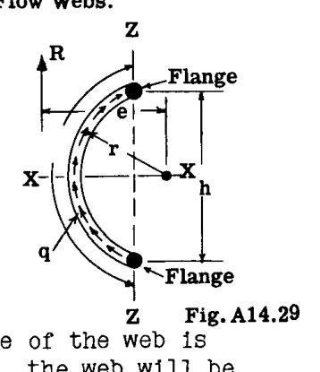

図 A14.29